# Tooth Growth Data Inference

Baoshi Sun

## Overview

In this report, we are going to perform some exploratory analyses on the ToothGrowth data in the R datasets package and try to reach conclusions based on the results of the confidence intervals and hypothesis test.

## Exploratory Analysis

```
## 'data.frame':    60 obs. of  3 variables:
##  $ len : num  4.2 11.5 7.3 5.8 6.4 10 11.2 11.2 5.2 7 ...
##  $ supp: Factor w/ 2 levels "OJ","VC": 2 2 2 2 2 2 2 2 2 2 ...
##  $ dose: num  0.5 0.5 0.5 0.5 0.5 0.5 0.5 0.5 0.5 0.5 ...
```

```
##
## OJ VC
## 30 30
```

```
##
## 0.5   1   2
##  20  20  20
```

We have 60 samples of 3 variables in the dataset, which can be splitted into 2 groups evenly on variable supp (VC and OJ) with 3 amount of doses (0.5, 1, 2) in each group.

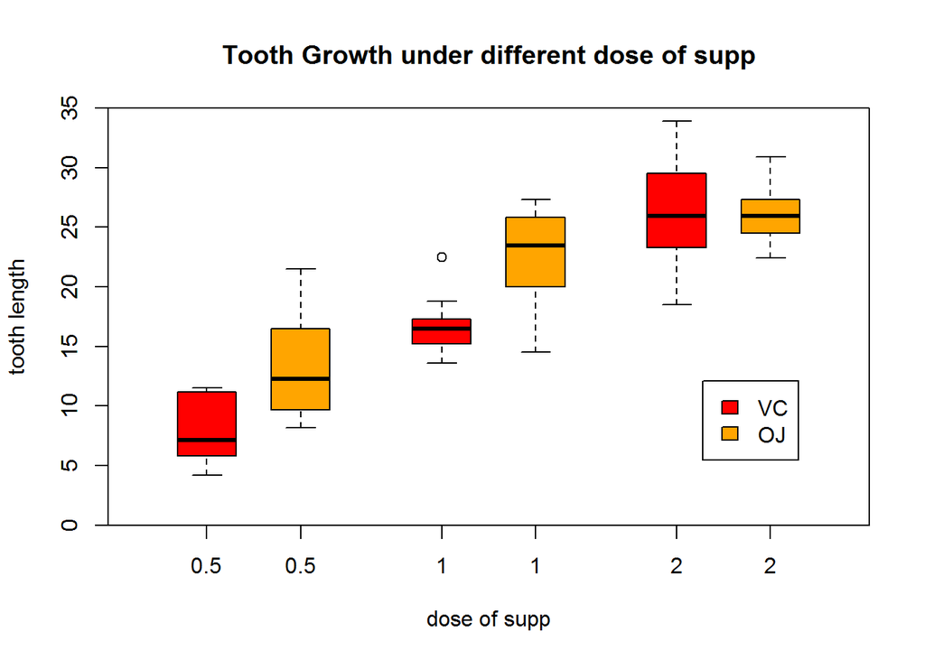

## Confidence Intervals on variable supp

```
##   supp count  mean   sd
## 1   VC    30 16.96 1.51
## 2   OJ    30 20.66 1.21
```

To verify the idea of OJ having better outcome over VC, we divide the data into two small-sample groups on variable supp. Because the groups are independent, we are using indenpendent group t confidence intervals with equal variance.

```
## [1] -0.1670064  7.5670064
## attr(,"conf.level")
## [1] 0.95
```

```
## [1] 0.4708204 6.9291796
## attr(,"conf.level")
## [1] 0.9
```

Let us construct both 95% and 90% T intervals for supp comparing OJ to VC (substracting in order of OJ - VC). As can be seen, under in confidence level 95% the lower end of the T interval is below zero, whereas the interval is entirely above zero if we set the confidence level to 90%.

## Hypothesis Testing on variable dose

```
##   dose count  mean   sd
## 1  0.5    20 10.61 1.01
## 2  1.0    20 19.73 0.99
## 3  2.0    20 26.10 0.84
```

### Hypothesis Testing 1: dose 1 on does 0.5

- $H_0 : \mu = 10.61$
- $H_a : \mu > 10.61$  
  When tested under 95% confidence level, we got p-value 6.331484810^{-8}, which is less than $\alpha = 0.05$. Therefore, we can reject the null hypotheis.

### Hypothesis Testing 1: dose 2 on does 1

- $H_0 : \mu = 19.73$
- $H_a : \mu > 19.73$  
  When tested under 95% confidence level, we got p-value 9.054142710^{-6}, which is less than $\alpha = 0.05$ too. Thus we reject the null hypotheis again.

## Conclusions

From above analysis, concusions can be made under the following assumptions:  
* Samples in ToothGrowth dataset are randomly drawn from the same population, which means the 30 samples are independent and identically distributed (iid)  
* Although with limited amount of samples in each subset, we assume the data are normally distributed

- Conclusion 1: With 90% confidence level, the OJ has better effect than VC on the growth of tooth.
- Conclusion 2: With 95% confidence level, dose 2 has greater effect than dose 1. The same result is observed for dose 1 on dose 0.5.

## Appendix: source code for the report

```r
data(ToothGrowth)
str(ToothGrowth)
table(ToothGrowth$supp); table(ToothGrowth$dose)

#with(ToothGrowth, {
#    boxplot(len ~ dose, boxwex = 0.25, at = 1:3 - 0.2,
#        subset = supp == "VC", col = "red",
#        main = "Tooth Growth under different dose of supp",
#        xlab = "dose of supp", ylab = "tooth length",
#        xlim = c(0.5, 3.5), ylim = c(0, 35), yaxs = "i")
#    boxplot(len ~ dose, add = TRUE, boxwex = 0.25, at = 1:3 + 0.2,
#        subset = supp == "OJ", col = "orange")
#    legend(2.91, 12.1, c("VC", "OJ"), fill = c("red", "orange"))
#})

g_vc <- ToothGrowth$len[ToothGrowth$supp == "VC"]
g_oj <- ToothGrowth$len[ToothGrowth$supp == "OJ"]
n_vc <- length(g_vc); n_oj <- length(g_oj)
m_vc <- round(mean(g_vc), 2); m_oj <- round(mean(g_oj), 2)
s_vc <- round(sd(g_vc) / sqrt(n_vc), 2); s_oj <- round(sd(g_oj) / sqrt(n_oj), 2)

sum_supp <- data.frame(rbind(c("VC", n_vc, m_vc, s_vc), c("OJ", n_oj, m_oj, s_oj)))
names(sum_supp) <- c("supp", "count", "mean", "sd")
#sum_supp

t.test(g_oj, g_vc, paired=FALSE, var.equal=TRUE)$conf
t.test(g_oj, g_vc, paired=FALSE, var.equal=TRUE, conf.level = 0.9)$conf

g_dose1 <- ToothGrowth$len[ToothGrowth$dose == 0.5]
g_dose2 <- ToothGrowth$len[ToothGrowth$dose == 1]
g_dose3 <- ToothGrowth$len[ToothGrowth$dose == 2]
n_dose1 <- length(g_dose1); n_dose2 <- length(g_dose2); n_dose3 <- length(g_dose3)
m_dose1 <- round(mean(g_dose1), 2)
m_dose2 <- round(mean(g_dose2), 2)
m_dose3 <- round(mean(g_dose3), 2)
s_dose1 <- round(sd(g_dose1) / sqrt(n_dose1), 2)
s_dose2 <- round(sd(g_dose2) / sqrt(n_dose2), 2)
s_dose3 <- round(sd(g_dose3) / sqrt(n_dose3), 2)

sum_dose <- data.frame(rbind(c(0.5, n_dose1, m_dose1, s_dose1), c(1, n_dose2, m_dose2, s_dose2), c(2, n_dose3, m_dose3, s_dose3)))
names(sum_dose) <- c("dose", "count", "mean", "sd")
#sum_dose

ht_d1 <- t.test(g_dose2, g_dose1, paired=FALSE, var.equal=TRUE, alternative="greater")
al_d1 <- ht_d1$alternative; pv_d1 <- ht_d1$p.value
ht_d2 <- t.test(g_dose3, g_dose2, paired=FALSE, var.equal=TRUE, alternative="greater")
al_d2 <- ht_d2$alternative; pv_d2 <- ht_d2$p.value
#ht_d1; ht_d2
```